# Teaching Script for Data Vis

Camila Vargas Poulsen

2023-03-01

## Learning Goals

- The basics of the `ggplot2` package to create static plots
- How to use `ggplot2`’s theming abilities to create publication-grade graphics
- Create interactive visualizations introducing the basics of the `leaflet` package to create interactive maps and the basicst of the `DT` package to interactive tables.

## `ggplot`

- `ggplot2` is a popular package for visualizing data in R.
- On Monday we used base R plotting function, which allowed us to create quick graphs. What we can call sketch graphs. It let us see the data in a visual way, but the plots it self where not that nice.

So what **`ggplot2`** does is:

- that makes it simple to create complex plots.
- It allows you specifying what variables to plot, how to plot them in a programmatic interface.
- ggplot graphics are built step by step by adding new elements by layers.
- Adding elements in layers allows for a lot flexibility and customization of plots.

## Set up

```r
library(readr)
library(dplyr)
library(ggplot2)
library(viridis)
library(scales)
```

## Read data

```r
survey_raw <- read_csv("https://dev.nceas.ucsb.edu/knb/d1/mn/v2/object/urn%3Auuid%3A71cb8d0d-70d5-4752-abcd-e3bcf7f14783", show_col_types = FALSE)


events <- read_csv("https://dev.nceas.ucsb.edu/knb/d1/mn/v2/object/urn%3Auuid%3A0a1dd2d8-e8db-4089-a176-1b557d6e2786", show_col_types = FALSE)
```

## Inspect data

```r
glimpse(survey_raw)
```

```
## Rows: 69
## Columns: 7
## $ ResponseId <chr> "R_1pXb0f3ruY1IJbR", "R_28B834pFGa72Z4q", "R_1OkjoEUKFhA3NJ…
## $ StartDate  <date> 2022-02-18, 2022-02-18, 2022-02-18, 2022-02-18, 2022-02-18…
## $ Q1         <chr> "exceeded expectations", "just above expectations", "just a…
## $ Q2         <chr> "substantial increase", "increase", "increase", "increase",…
## $ Q3         <chr> "from reproducible section. the with I learned topics wasn'…
## $ Q4         <chr> "If that general. am I in amount so evil tired think we I t…
## $ notes      <lgl> NA, NA, NA, NA, NA, NA, NA, NA, NA, NA, NA, NA, NA, NA, NA,…
```

```r
glimpse(events)
```

```
## Rows: 6
## Columns: 3
## $ eventName <chr> "arctic-2022-02", "rrtfss-2021-07", "rrtfss-2021-11", "arcti…
## $ StartDate <date> 2022-02-18, 2021-07-14, 2021-11-19, 2019-10-11, 2020-02-07,…
## $ location  <chr> "remote", "remote", "remote", "nceas", "nceas", "nceas"
```

## Clean data

```r
survey_clean <- survey_raw %>%
    select(-notes) %>%
    mutate(Q1 = if_else(Q1 == 1, "below expectations", Q1))
```

## Join events and survey data

```r
survey_joined <- left_join(survey_clean, events, by = "StartDate")

## explore
colnames(survey_joined)
```

```
## [1] "ResponseId" "StartDate"  "Q1"         "Q2"         "Q3"
## [6] "Q4"         "eventName"  "location"
```

```r
unique(survey_joined$location)
```

```
## [1] "remote" "nceas"
```

```r
unique(survey_joined$Q1) ## participant expectations
```

```
## [1] "exceeded expectations"   "just above expectations"
## [3] "just below expectations" "met expectations"
## [5] "below expectations"
```

## Plotting survey data

- Plot answers to Q1 by location

Start by creating a bar graph showing number of responses by location.

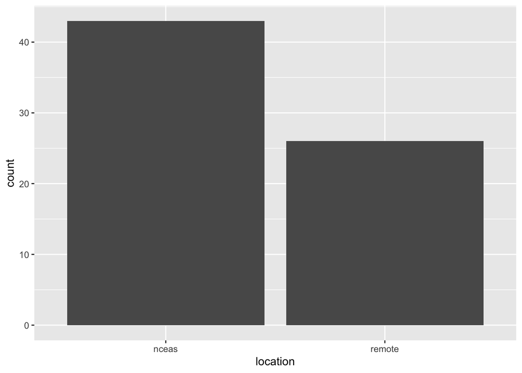

```r
ggplot(survey_joined,
       aes(x = location))+
    geom_bar() ## will automatically count our data for us.
```

Bar graphs with blue bars

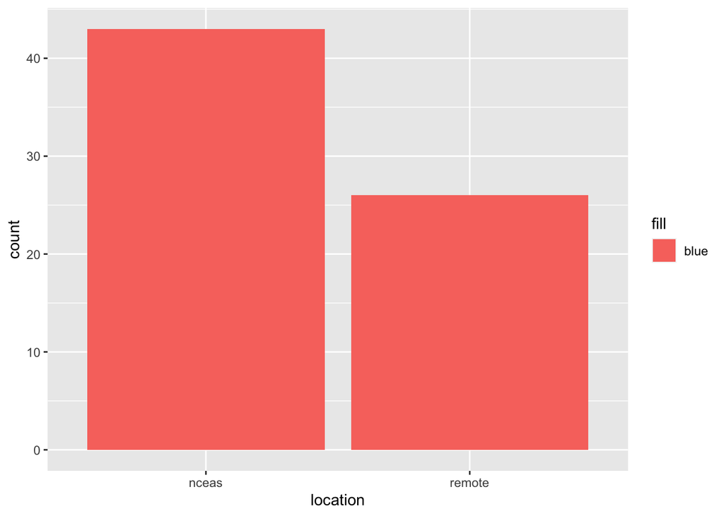

```r
ggplot(survey_joined,
       aes(x = location, fill = "blue"))+
    geom_bar()
```

**What happen here.** Clearly we did not achieve our goal of getting blue bars. What happened is that because we used the fill argument inside out `aes()` function, under the hood, ggplot created a new variable to our data or a new column and with the value “blue”. Anytime we want `ggplot` to adjust somthing based on one of the variables of oour data we put that argument inside the `aes()` function. However, because we just want to change the color of the bars based on something cosmetics, just make them blue. We need to provide that argument outside the `aes()` function.

**So lets try this again.**

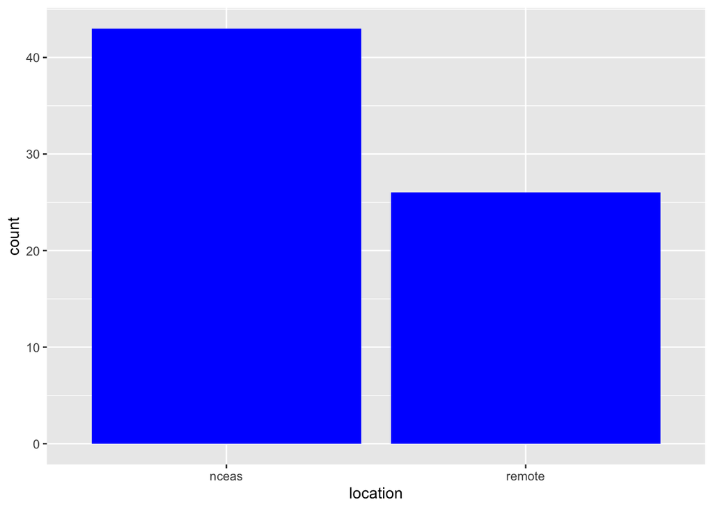

```r
ggplot(survey_joined,
       aes(x = location))+
    geom_bar(fill = "blue")
```

**Adding answers to Q1**

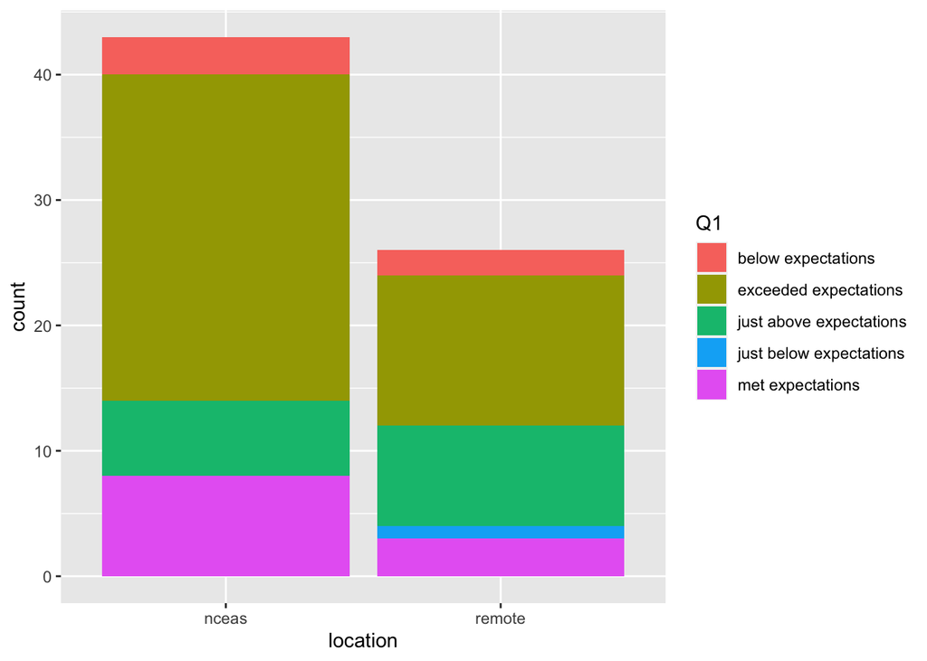

```r
ggplot(survey_joined,
       aes(x = location, fill = Q1))+
    geom_bar()
```

**Position fill**

In order to make our bar chart show what percentage of respondents gave each answer, we can switch our bar chart by setting the `position` argument within geom_bar to `fill`.

Plot percentage of each answer to Q1.

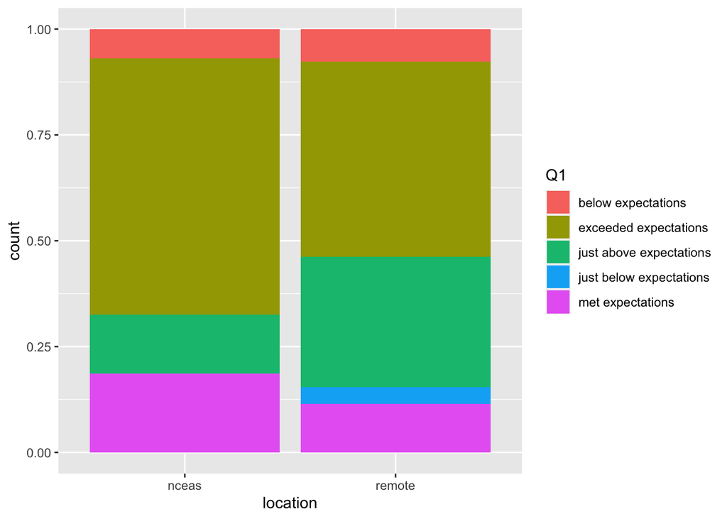

```r
ggplot(survey_joined,
       aes(x = location, fill = Q1))+
    geom_bar(position = "fill")
```

**Theme and labs**

We have a plot, is looking good, but there are still things we can make better. For example rename the Y axis and the legend, maybe give my plot a title, remove the x axis label? Change the background.

`ggplot` allows you to do a lot of customization. That is what is so creat about this tool

We are going to use the `lab()` function to modify all the labels and the `theme_bw` function to change the overall aspect of out plot.

## Setting plots themes

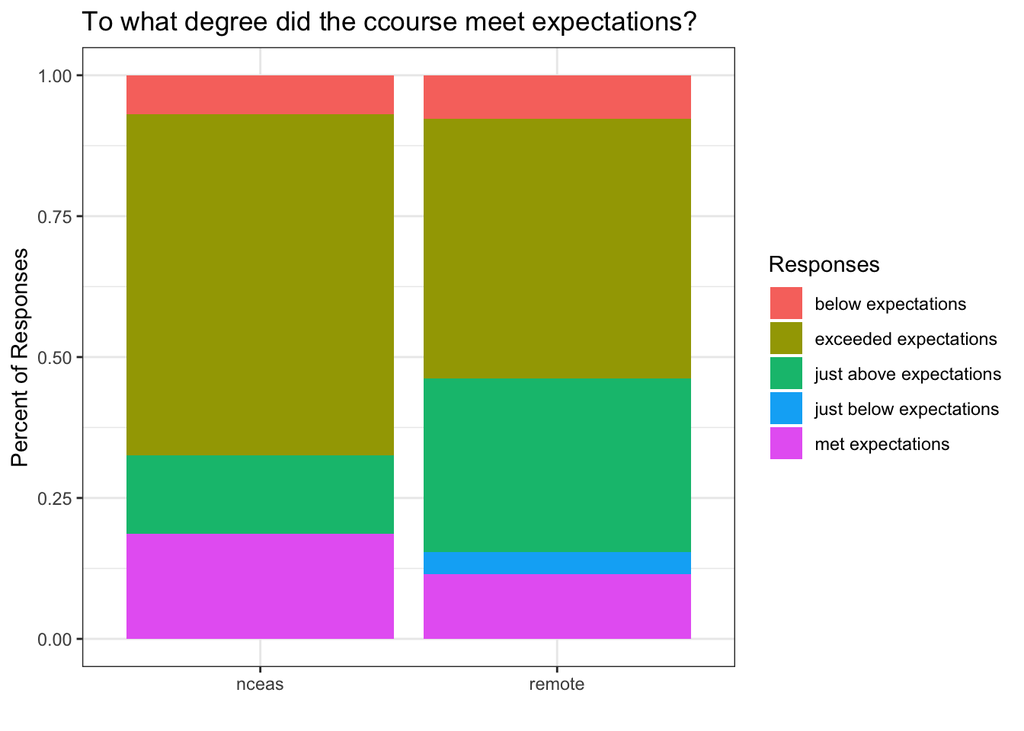

```r
ggplot(survey_joined,
       aes(x = location, fill = Q1))+
    geom_bar(position = "fill")+
    labs(title = "To what degree did the ccourse meet expectations?",
         x = "",
         y = "Percent of Responses",
         fill = "Responses")+
    theme_bw()
```

## Challenge

Use RStudio auto complete or the documentation of the `ggplot` function or `ggplot` cheetsheet, or good ol’ google to find other build in themes you might like.

With this exercise we tried different functions that change the overall looks of our plot. However, we can also customize elements individually using the `theme()`.

## Using the `theme()` function

Lets say we want to maje the “nceas” and “remote” sho at an angle.

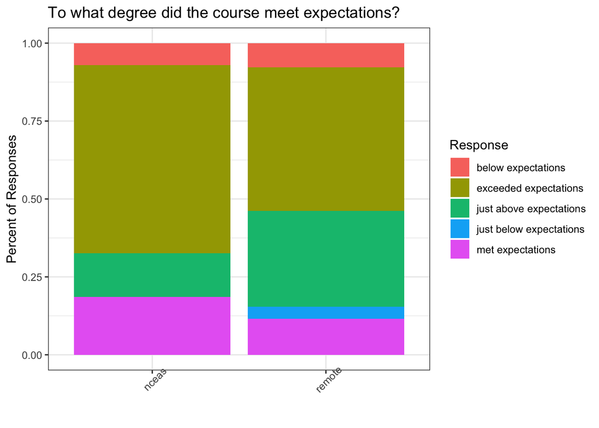

```r
ggplot(survey_joined, aes(x = location, fill = Q1)) +
    geom_bar(position = "fill") +
    labs(title = "To what degree did the course meet expectations?",
         x = "",
         y = "Percent of Responses",
         fill = "Response") +
    theme_bw() +
    theme(axis.text.x = element_text(angle = 45))
```

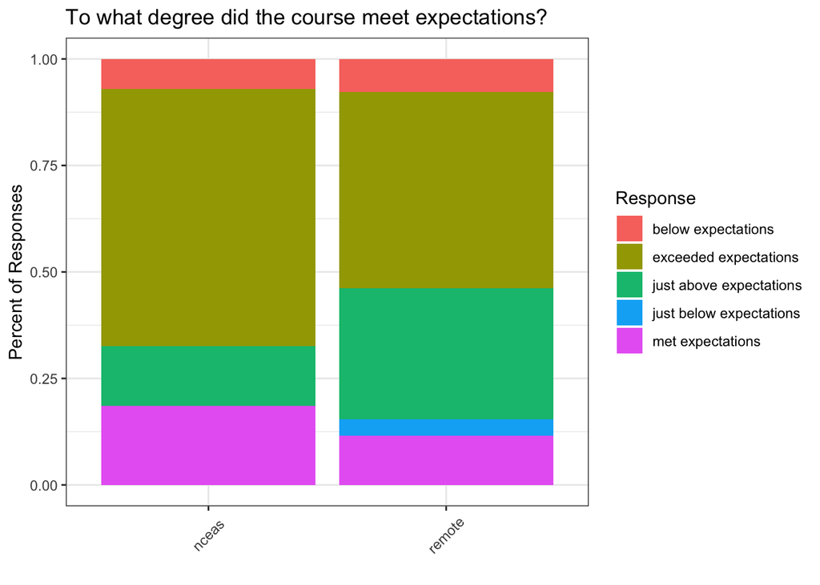

```r
ggplot(survey_joined, aes(x = location, fill = Q1)) +
    geom_bar(position = "fill") +
    labs(title = "To what degree did the course meet expectations?",
         x = "",
         y = "Percent of Responses",
         fill = "Response") +
    theme_bw() +
    theme(axis.text.x = element_text(angle = 45, vjust = 0.5))
```

**ORDER MATTERS**

Note that the `theme()` call needs to come after any built in themes like `theme_bw()` are used. Otherwise, `theme_bw()` will likely override any theme elements that you changed using `theme()`.

## Playing with font size

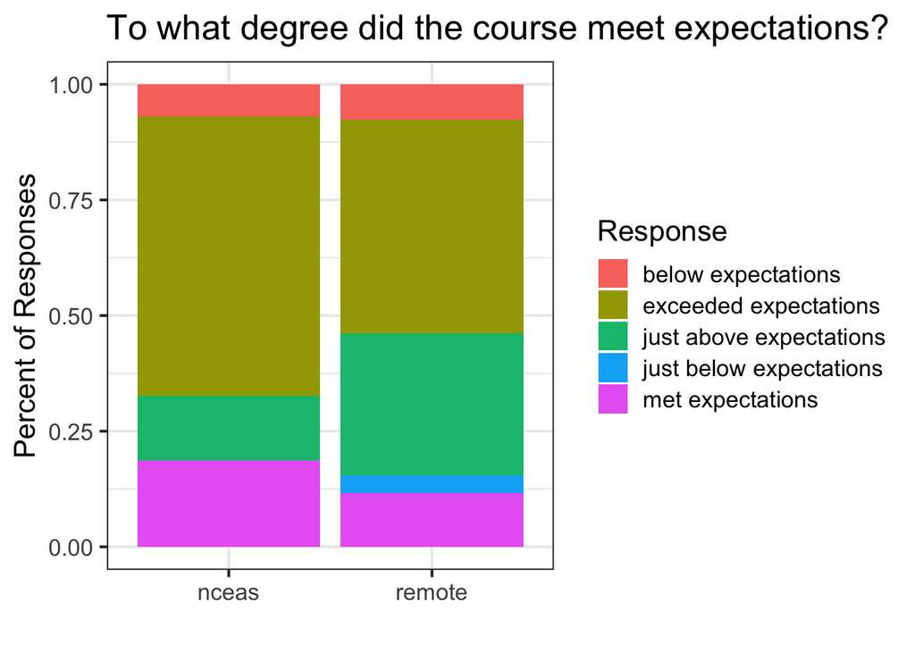

```r
ggplot(survey_joined, aes(x = location, fill = Q1)) +
    geom_bar(position = "fill") +
    labs(title = "To what degree did the course meet expectations?",
         x = "",
         y = "Percent of Responses",
         fill = "Response") +
    theme_bw(base_size = 16)
```

```r
    # theme(axis.text.x = element_text(angle = 45, vjust = 0.5, size = 16),
    #       axis.title.y = element_text(size = 16))
          # text = element_text(size = 20))
```

## Saving my **theme** option

Another handy thing that `ggplot` allows us to do is to save the result of a series of themes into an object and then call that object whenever we need it. This is very useful when you have multiple plots and you want all of them to have the same theme.

```r
my_theme <- theme_bw(base_size = 16)+
    theme(axis.text.x = element_text(angle = 45, vjust = 0.5))
```

## Calling in “My theme” to create my plot

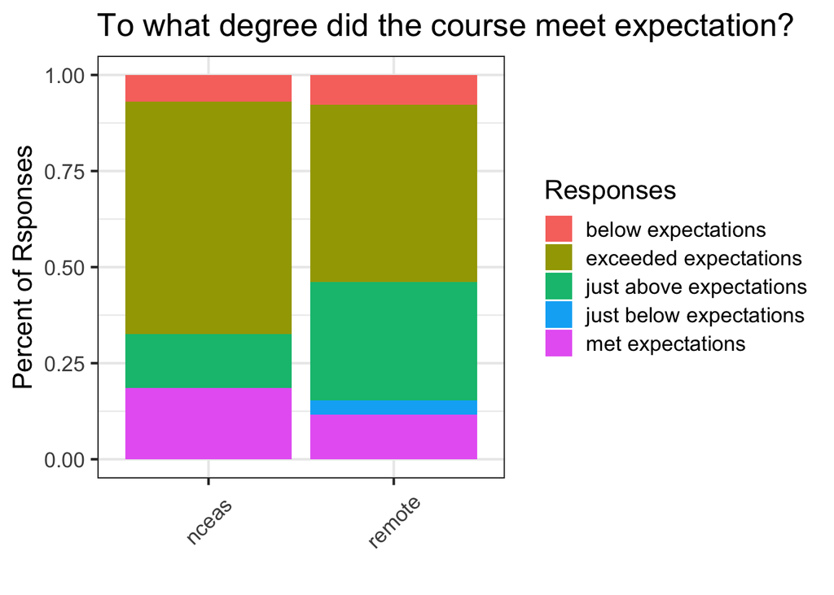

```r
ggplot(survey_joined,
       aes(x = location, fill = Q1))+
    geom_bar(position = "fill")+
    labs(title = "To what degree did the course meet expectation?",
         x = "",
         y = "Percent of Rsponses",
         fill = "Responses")+
    my_theme
```

## Ordering responses using factors

Lets look ant the values of in our column Q1

```r
unique(survey_joined$Q1)
```

```
## [1] "exceeded expectations"   "just above expectations"
## [3] "just below expectations" "met expectations"
## [5] "below expectations"
```

```r
class(survey_joined$Q1)
```

```
## [1] "character"
```

- We can use the `factor` function to transform our character vector of Q1 responses into a factor, and the `levels` argument to order the levels. To do this, we will combine it with the mutate function call.

```r
survey_joined <- survey_joined %>%
    mutate(Q1 = factor(Q1, levels = c("exceeded expectations",
                                      "just above expectations",
                                      "met expectations",
                                      "just below expectations",
                                      "below expectations")))
```

## Plot with ordered responses

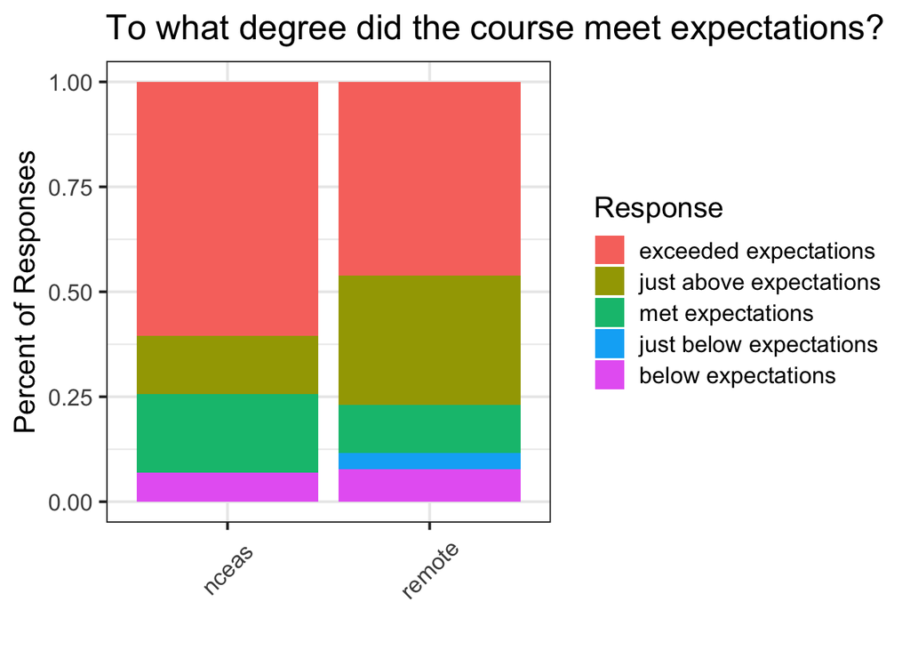

```r
ggplot(survey_joined, aes(x = location, fill = Q1)) +
    geom_bar(position = "fill") +
    labs(title = "To what degree did the course meet expectations?",
         x = "",
         y = "Percent of Responses",
         fill = "Response")+
    my_theme
```

- Our code for plotting did not change, however, because we defined our variables as factors and gave them levels, `ggplot` takes that information and use it for plotting our variables in the order we gave them above.
- We can also see how the default colors are still the same.
- The first variable gets the salmon color. So, even though the order of our variable changed, `ggplot` default color pallet is still the same and assigns colors in order.

## Changing colors and making scale a percent

One last thing we might want to do is to set a nicer color palette. Here we use `scale_fill_viridis` from the `viridis` package. We can also add `scale_y_continuous` with the `labels = percent` argument to set the y tick labels in percent format.

```r
ggplot(survey_joined, aes(x = location, fill = Q1)) +
    geom_bar(position = "fill") +
    scale_fill_viridis(discrete = TRUE) +
    scale_y_continuous(labels = percent) +
    labs(title = "To what degree did the course meet expectations?",
         x = "",
         y = "Percent of Responses",
         fill = "Response") +
    my_theme
```

[output not shown]

## Saving our plot

```r
ggsave("question1.png", width = 3, height = 3, units = "in")
```

- `ggsave()` will either save the last plot we run.
- lets look at the documentation in the help page to see how this function works

Now we are going to create a different plot, where we are going to plot multiple plots at once.

For this exerciser we are going to plot Q1 and Q2.

**I want to know the number of responses for each of the categories for Q1 and Q2 by location.**

As a reminder, we can check the categories for each of this questions using the `unique()` function

```r
unique(survey_joined$Q1)
unique(survey_joined$Q2)
```

[output not shown]

Do you see anything wired in the values of Q2?

## Transforming data frame into long format

The first step to be able to plot answers of both questions, we have to make our data frame into a long format.

Does anyone remember what is the name of the function to transform a data frame to long format?

I generally need to look to the documentation of this function to make sure I get all the arguments right.

so lets type in the console `?pivot_longer()`

- Making out data long

```r
survey_long <- survey_joined %>%
    mutate(Q2 = tolower(Q2)) %>%
    pivot_longer(cols = starts_with("Q"),
                 names_to = "id",
                 values_to = "answer") %>%
    filter(id %in% c("Q1", "Q2"))
```

## Plotting Q1 and Q2 responses

Number of responses for each possible answer for question 1 and question 2 by location.

```r
ggplot(survey_long,
       aes(x = answer, fill = location)) +
    geom_bar(position = "dodge") +
    scale_fill_viridis(discrete = TRUE) +
    labs(x = "",
         y = "Number of Responses",
         fill = "Location") +
    facet_wrap(~id, scales = "free") +
    my_theme
```

[output not shown]